# Machine learning assignment

Triin Kask

3 January 2018

# Practical machine learning course assignment

## Synopsis

Using devices such as Jawbone Up, Nike FuelBand, and Fitbit it is now possible to collect a large amount of data about personal activity relatively inexpensively. These type of devices are part of the quantified self movement - a group of enthusiasts who take measurements about themselves regularly to improve their health, to find patterns in their behavior, or because they are tech geeks. One thing that people regularly do is quantify how much of a particular activity they do, but they rarely quantify how well they do it. In this project, your goal will be to use data from accelerometers on the belt, forearm, arm, and dumbell of 6 participants. They were asked to perform barbell lifts correctly and incorrectly in 5 different ways. More information is available from the website here: http://groupware.les.inf.puc-rio.br/har (see the section on the Weight Lifting Exercise Dataset). Read more: http://groupware.les.inf.puc-rio.br/har#ixzz3xsbS5bVX

This assignment was built up in RStudio, using its knitr functions, meant to be published in html format. The main goal of the project is to predict the manner in which 6 participants performed some exercise as described below. This is the “classe” variable in the training set. The machine learning algorithm described here is applied to the 20 test cases available in the test data and the predictions are submitted in appropriate format to the Course Project Prediction Quiz for automated grading.

## Obtaining data

The training data for this project are available here:

https://d396qusza40orc.cloudfront.net/predmachlearn/pml-training.csv

The test data are available here:

https://d396qusza40orc.cloudfront.net/predmachlearn/pml-testing.csv

The data for this project come from http://groupware.les.inf.puc-rio.br/har.

### Reading files

```r
filepath1 <- "https://d396qusza40orc.cloudfront.net/predmachlearn/pml-training.csv"
filepath2 <- "https://d396qusza40orc.cloudfront.net/predmachlearn/pml-testing.csv"

if(!file.exists("pml-training.csv")) {
  download.file(filepath1, destfile = "pml-training.csv")
}

if(!file.exists("pml-testing.csv")) {
  download.file(filepath2, destfile = "pml-testing.csv")
}
test <- read.csv("pml-testing.csv", sep = ",", header = TRUE, na.strings=c("NA","#DIV/0!",""))
training <- read.csv("pml-training.csv", sep = ",", header = TRUE, na.strings=c("NA","#DIV/0!",""))
```

### Cleaning data

In this section columns that contain NAs or are empty are removed. First seven features are not numeric (related to the time-series)

```r
features <- names(test[,colSums(is.na(test)) == 0])[8:46]

# Since test and training sets are compared, use only features that are present in the testing set.
training <- training[,c(features,"classe")]
test <- test[,c(features,"problem_id")]
```

### Create partitions

For machine training session one must create partitions for it first. In this case 70% training set and 30% testing set will be created from the dataset provided.

```r
library(caret)
Partitions  <- createDataPartition(training$classe, p=0.7, list=FALSE)
Train_set <- training[Partitions, ]
Test_set  <- training[-Partitions, ]
dim(Train_set)
```

```
## [1] 13737    40
```

```r
dim(Test_set)
```

```
## [1] 5885   40
```

### Correlation analysis

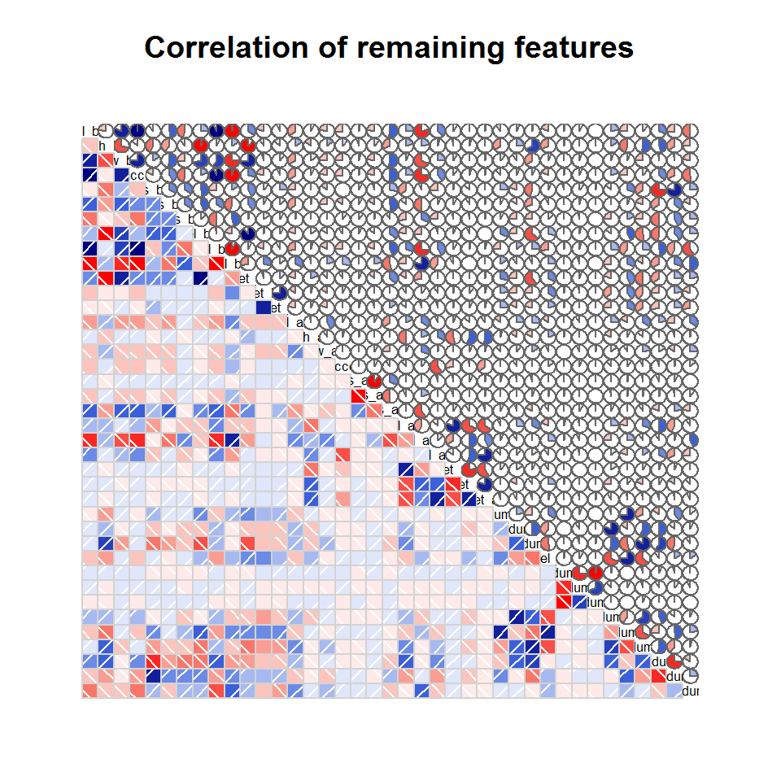

```r
#Plot
library(corrgram)
corrgram(Train_set, order=FALSE, lower.panel=panel.shade, upper.panel=panel.pie, text.panel=panel.txt, col.regions=colorRampPalette(c("red","salmon","white","royalblue","navy")), main="Correlation of remaining features")
```

Only few very dark correlation can be found.

## Model selection

Two models will be used in this data analysis: random forests and decision trees. Confusion matrices are plotted to show their accuracy.

### Random forest analysis on the training dataset

```r
library(randomForest)
library(caret)
set.seed(12345)
random_forest_model <- randomForest(classe ~ ., data = Train_set, ntree = 1000, na.action =na.exclude)

#Use prediction on testing set of training set result
prediction <- predict(random_forest_model, Test_set, type = "class")
confusionMatrix(prediction, Test_set$classe)
```

```
## Confusion Matrix and Statistics
##
##           Reference
## Prediction    A    B    C    D    E
##          A 1671   16    1    1    0
##          B    1 1110    7    0    0
##          C    0   13 1013    9    3
##          D    2    0    5  953    1
##          E    0    0    0    1 1078
##
## Overall Statistics
##
##                Accuracy : 0.9898
##                  95% CI : (0.9869, 0.9922)
##     No Information Rate : 0.2845
##     P-Value [Acc > NIR] : < 2.2e-16
##
##                   Kappa : 0.9871
##  Mcnemar's Test P-Value : NA
##
## Statistics by Class:
##
##                      Class: A Class: B Class: C Class: D Class: E
## Sensitivity            0.9982   0.9745   0.9873   0.9886   0.9963
## Specificity            0.9957   0.9983   0.9949   0.9984   0.9998
## Pos Pred Value         0.9893   0.9928   0.9759   0.9917   0.9991
## Neg Pred Value         0.9993   0.9939   0.9973   0.9978   0.9992
## Prevalence             0.2845   0.1935   0.1743   0.1638   0.1839
## Detection Rate         0.2839   0.1886   0.1721   0.1619   0.1832
## Detection Prevalence   0.2870   0.1900   0.1764   0.1633   0.1833
## Balanced Accuracy      0.9970   0.9864   0.9911   0.9935   0.9980
```

### Out-of-sample error for random forest

```r
sum(prediction != Test_set$classe) / length(Test_set$classe)
```

```
## [1] 0.01019541
```

### Random forest analysis result on the testing dataset

```r
predict(random_forest_model, test, type = "class")
```

```
##  1  2  3  4  5  6  7  8  9 10 11 12 13 14 15 16 17 18 19 20
##  B  A  B  A  A  E  D  B  A  A  B  C  B  A  E  E  A  B  B  B
## Levels: A B C D E
```

### Train a decision tree model

```r
library(rattle)
library(rpart)
```

[figure not shown]

```r
#Create random sample without NAs
set.seed(55555)
#training <- Train_set[ , colSums(is.na(Train_set)) == 0]
rand_sample <- Train_set[sample(1:nrow(Train_set), 100, replace = FALSE), ]

#Train random sample using decision tree with principal componend analysis
dt_mod <- rpart(classe~., data=rand_sample, method="class")
fancyRpartPlot(dt_mod)
```

Decision tree model shows somewhat equal prediction amongst classes.

### Use decision tree on test-set and plot a confusion matrix

```r
dt_model <- rpart(classe~., data=Test_set, method="class")
prediction_dt <- predict(dt_model, Test_set, type = "class")
confusionMatrix(prediction_dt, Test_set$classe)
```

```
## Confusion Matrix and Statistics
##
##           Reference
## Prediction    A    B    C    D    E
##          A 1387  181   71   36   15
##          B   43  629   45   16   58
##          C   80   87  708  138   67
##          D  145  241  202  760  225
##          E   19    1    0   14  717
##
## Overall Statistics
##
##                Accuracy : 0.7138
##                  95% CI : (0.7021, 0.7254)
##     No Information Rate : 0.2845
##     P-Value [Acc > NIR] : < 2.2e-16
##
##                   Kappa : 0.6392
##  Mcnemar's Test P-Value : < 2.2e-16
##
## Statistics by Class:
##
##                      Class: A Class: B Class: C Class: D Class: E
## Sensitivity            0.8286   0.5522   0.6901   0.7884   0.6627
## Specificity            0.9280   0.9659   0.9234   0.8348   0.9929
## Pos Pred Value         0.8207   0.7952   0.6556   0.4832   0.9547
## Neg Pred Value         0.9316   0.8999   0.9338   0.9527   0.9289
## Prevalence             0.2845   0.1935   0.1743   0.1638   0.1839
## Detection Rate         0.2357   0.1069   0.1203   0.1291   0.1218
## Detection Prevalence   0.2872   0.1344   0.1835   0.2673   0.1276
## Balanced Accuracy      0.8783   0.7591   0.8067   0.8116   0.8278
```

```r
sum(prediction_dt != Test_set$classe) / length(Test_set$classe)
```

```
## [1] 0.2861512
```

## 20 different test case prediction

```r
predict_test <- predict(random_forest_model, newdata=test)
test$problem_id <- predict_test
result <- data.frame(problem_id = test$problem_id, classe = predict_test)
result[1:20,]
```

```
##    problem_id classe
## 1           B      B
## 2           A      A
## 3           B      B
## 4           A      A
## 5           A      A
## 6           E      E
## 7           D      D
## 8           B      B
## 9           A      A
## 10          A      A
## 11          B      B
## 12          C      C
## 13          B      B
## 14          A      A
## 15          E      E
## 16          E      E
## 17          A      A
## 18          B      B
## 19          B      B
## 20          B      B
```